# assignment #3

20141831 박석환

### import data

자료 가져오기

```r
climate <- read.csv('ClimateChange.csv')
str(climate)
```

```
## 'data.frame':    308 obs. of  11 variables:
##  $ Year    : int  1983 1983 1983 1983 1983 1983 1983 1983 1984 1984 ...
##  $ Month   : int  5 6 7 8 9 10 11 12 1 2 ...
##  $ MEI     : num  2.556 2.167 1.741 1.13 0.428 ...
##  $ CO2     : num  346 346 344 342 340 ...
##  $ CH4     : num  1639 1634 1633 1631 1648 ...
##  $ N2O     : num  304 304 304 304 304 ...
##  $ CFC.11  : num  191 192 193 194 194 ...
##  $ CFC.12  : num  350 352 354 356 357 ...
##  $ TSI     : num  1366 1366 1366 1366 1366 ...
##  $ Aerosols: num  0.0863 0.0794 0.0731 0.0673 0.0619 0.0569 0.0524 0.0486 0.0451 0.0416 ...
##  $ Temp    : num  0.109 0.118 0.137 0.176 0.149 0.093 0.232 0.078 0.089 0.013 ...
```

### assignment 3-1-1

**Year 및 Month를 제외한 9개의 변수들 간의 상관 관계를 다양한 그래프를 활용하여 시각화해보고, 이로 부터 데이터의 특성을 분석해보자.**

### 변수간 상관관계 시각화

Year 및 Month를 제거 한 후 ggpairs 함수를 통해 변수간 상관관계 시각화

```r
library(GGally)
```

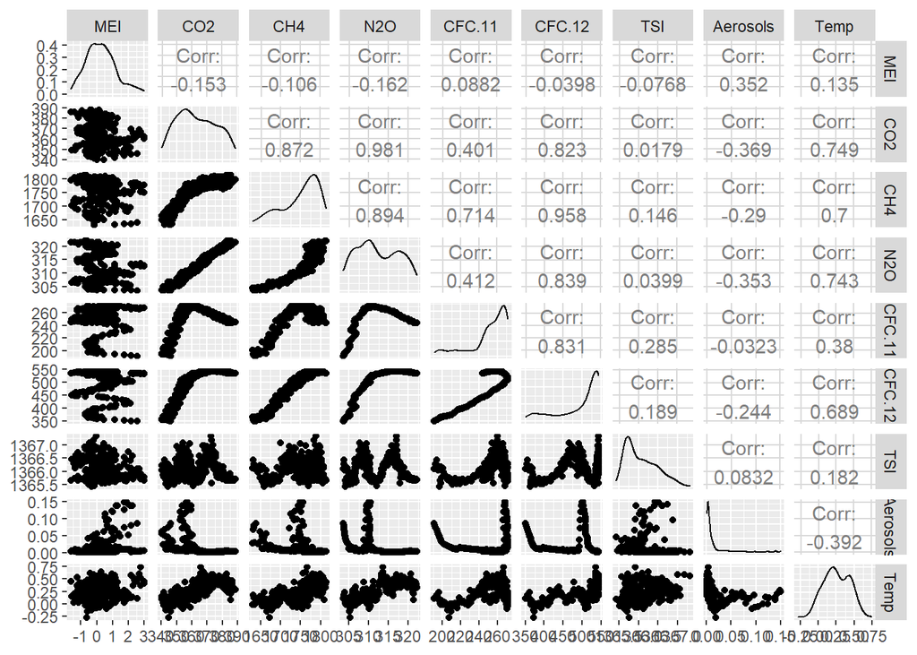

```r
re <- ggpairs(climate,3:11)
re
```

### 데이터 특성 분석

그래프의 결과를 보면 대부분의 데이터가 일반적인 정규분포나 한쪽으로 치우친 정규분포를 따른다고 볼 수 있다.

Target 변수인 Temp와 상관관계가 높은 feature로 “CO2, CH4, N2O, CFC12”등이 있다. feature들중 Aerosols만 유일하게 온도와 음의 상관관계를 갖고 있기 때문에 서로 반비례 관계임을 알 수 있다.

### assignment 3-1-2

**2004년 이후의 데이터를 test set으로 2003년까지의 데이터를 training set으로 분할하자. 그리고 training set을 활용하여 linear regression model을 수립하자. 이때 8개의 feature변수를 모두 포함 시킨다.**

### 데이터 전처리

2004년을 기준으로 데이터를 Training set과 Test set으로 분할한다. 이때 Year와 Month의 값은 빼준다.

```r
climate_train <- subset(climate, Year <= 2003)
climate_test <- subset(climate, Year >= 2004)
climate_train <- climate_train[c(-1,-2)]
climate_test <- climate_test[c(-1,-2)]

str(climate_train)
```

```
## 'data.frame':    248 obs. of  9 variables:
##  $ MEI     : num  2.556 2.167 1.741 1.13 0.428 ...
##  $ CO2     : num  346 346 344 342 340 ...
##  $ CH4     : num  1639 1634 1633 1631 1648 ...
##  $ N2O     : num  304 304 304 304 304 ...
##  $ CFC.11  : num  191 192 193 194 194 ...
##  $ CFC.12  : num  350 352 354 356 357 ...
##  $ TSI     : num  1366 1366 1366 1366 1366 ...
##  $ Aerosols: num  0.0863 0.0794 0.0731 0.0673 0.0619 0.0569 0.0524 0.0486 0.0451 0.0416 ...
##  $ Temp    : num  0.109 0.118 0.137 0.176 0.149 0.093 0.232 0.078 0.089 0.013 ...
```

```r
str(climate_test)
```

```
## 'data.frame':    60 obs. of  9 variables:
##  $ MEI     : num  0.308 0.33 -0.125 0.216 0.47 0.17 0.472 0.669 0.524 0.467 ...
##  $ CO2     : num  377 378 379 380 381 ...
##  $ CH4     : num  1790 1798 1807 1806 1788 ...
##  $ N2O     : num  318 318 318 318 318 ...
##  $ CFC.11  : num  255 255 255 254 254 ...
##  $ CFC.12  : num  543 543 543 543 542 ...
##  $ TSI     : num  1366 1366 1366 1366 1366 ...
##  $ Aerosols: num  0.0025 0.0024 0.0024 0.0024 0.0022 0.0022 0.0023 0.0025 0.0025 0.0025 ...
##  $ Temp    : num  0.496 0.56 0.501 0.484 0.323 0.35 0.38 0.418 0.442 0.468 ...
```

### linear regression model 수립

Target 변수인 Temp를 제외한 나머지 8개의 feature들을 모두 포함시켜 linear regression model을 수립한다. 이때, train set을 활용한다.

```r
model_temp <- lm(Temp~., data=climate_train)
summary(model_temp)
```

```
##
## Call:
## lm(formula = Temp ~ ., data = climate_train)
##
## Residuals:
##      Min       1Q   Median       3Q      Max
## -0.25789 -0.06259 -0.00590  0.05567  0.32702
##
## Coefficients:
##               Estimate Std. Error t value Pr(>|t|)
## (Intercept) -1.385e+02  2.333e+01  -5.939 1.00e-08 ***
## MEI          6.528e-02  6.870e-03   9.501  < 2e-16 ***
## CO2          6.632e-03  2.643e-03   2.509 0.012768 *
## CH4          2.013e-04  5.939e-04   0.339 0.734969
## N2O         -2.525e-02  1.092e-02  -2.312 0.021635 *
## CFC.11      -7.666e-03  1.972e-03  -3.887 0.000131 ***
## CFC.12       4.557e-03  1.267e-03   3.598 0.000390 ***
## TSI          1.051e-01  1.792e-02   5.866 1.48e-08 ***
## Aerosols    -1.590e+00  2.269e-01  -7.010 2.42e-11 ***
## ---
## Signif. codes:  0 '***' 0.001 '**' 0.01 '*' 0.05 '.' 0.1 ' ' 1
##
## Residual standard error: 0.09482 on 239 degrees of freedom
## Multiple R-squared:  0.7133, Adjusted R-squared:  0.7037
## F-statistic: 74.32 on 8 and 239 DF,  p-value: < 2.2e-16
```

**assignment 3-1-2-(a)**

**어떠한 feature들이 Temp에 큰 영향을 미치는가?**

model_temp의 결과를 보면, “MEI, CFC.11, CFC.12, TSI, Aerosols”가 p-value가 충분히 작아 가장 큰 영향을 끼친다고 볼 수 있다.

그 다음으로 “CO2, N2O”의 p-value가 적당히 작아 좀 더 작은 영향을 끼친다고 볼 수 있다.

**assignment 3-1-2-(b)**

**N2O와 CFC-11은 지구의 지표면에서 우주로 발산하는 적외선 복사열을 흡수하여 지구 표면의 온도를 상승시키 는 역할을 하는 온실가스로 알려져 있다. 모델에서 N2O와 CFC-11 변수의 coefﬁcient는 양수 값을 가지는가? 음수 값을 가지는가? 만약 음수값을 가진다면 N2O와 CFC-11의 양이 증가할수록 평균 기온이 감소한다는 것을 의미하므로 일반적인 지식과 모순된다. 이러한 모순된 결과가 도출되는 원인은 무엇일까?**

model_temp의 결과를 보면 N2O는 -2.525e-02, CFC-11은 -7.666e-03로 각각 음의 값을 갖기 때문에 Temp에 음의 영향을 끼치는 것이 맞다.

하지만 N2O, CFC-11과 같이 높은 영향을 끼치는 MEI, CFC.12, TSI 등이 양의 관계를 갖고 있고, 이들의 영향이 더 크게 작용해 모순된 결과가 도출되었을 수도 있다.

### assignment 3-1-3

**MEI, TSI, Aerosols, N2O 4개의 feature만 사용하여 regression model을 만들어 보자.**

### 데이터 전처리

4가지의 feature만 갖는 regression model을 작성한다.

```r
model_4 <- lm(Temp ~ MEI + TSI + Aerosols + N2O, data = climate_train)
summary(model_4)
```

```
##
## Call:
## lm(formula = Temp ~ MEI + TSI + Aerosols + N2O, data = climate_train)
##
## Residuals:
##      Min       1Q   Median       3Q      Max
## -0.27840 -0.05990 -0.00633  0.05624  0.34294
##
## Coefficients:
##               Estimate Std. Error t value Pr(>|t|)
## (Intercept) -1.169e+02  2.315e+01  -5.052 8.58e-07 ***
## MEI          6.492e-02  7.089e-03   9.158  < 2e-16 ***
## TSI          8.003e-02  1.712e-02   4.674 4.89e-06 ***
## Aerosols    -1.708e+00  2.290e-01  -7.459 1.54e-12 ***
## N2O          2.524e-02  1.811e-03  13.933  < 2e-16 ***
## ---
## Signif. codes:  0 '***' 0.001 '**' 0.01 '*' 0.05 '.' 0.1 ' ' 1
##
## Residual standard error: 0.09935 on 243 degrees of freedom
## Multiple R-squared:  0.6799, Adjusted R-squared:  0.6747
## F-statistic: 129.1 on 4 and 243 DF,  p-value: < 2.2e-16
```

**assignment 3-1-3-(a)**

**N2O 변수의 coefﬁcient를 2번 모델과 비교해 보자.** 2번 모델 N2O coefficient : -2.525e-02

3번 모델 N2O coefficient : 2.524e-02

p-value 값이 더 유요해지면서 coefficient가 양수로 바뀐것을 알 수 있다.

**assignment 3-1-3-(b)**

**두 모델의 R2값, Adusted R2값, test set error (test set에 대한 RMSE) 를 비교해 보자. 어떤 모델을 선택 하겠는가?**

### R2값, Adusted R2값 비교

```r
summary(model_temp)
```

```
##
## Call:
## lm(formula = Temp ~ ., data = climate_train)
##
## Residuals:
##      Min       1Q   Median       3Q      Max
## -0.25789 -0.06259 -0.00590  0.05567  0.32702
##
## Coefficients:
##               Estimate Std. Error t value Pr(>|t|)
## (Intercept) -1.385e+02  2.333e+01  -5.939 1.00e-08 ***
## MEI          6.528e-02  6.870e-03   9.501  < 2e-16 ***
## CO2          6.632e-03  2.643e-03   2.509 0.012768 *
## CH4          2.013e-04  5.939e-04   0.339 0.734969
## N2O         -2.525e-02  1.092e-02  -2.312 0.021635 *
## CFC.11      -7.666e-03  1.972e-03  -3.887 0.000131 ***
## CFC.12       4.557e-03  1.267e-03   3.598 0.000390 ***
## TSI          1.051e-01  1.792e-02   5.866 1.48e-08 ***
## Aerosols    -1.590e+00  2.269e-01  -7.010 2.42e-11 ***
## ---
## Signif. codes:  0 '***' 0.001 '**' 0.01 '*' 0.05 '.' 0.1 ' ' 1
##
## Residual standard error: 0.09482 on 239 degrees of freedom
## Multiple R-squared:  0.7133, Adjusted R-squared:  0.7037
## F-statistic: 74.32 on 8 and 239 DF,  p-value: < 2.2e-16
```

```r
summary(model_4)
```

```
##
## Call:
## lm(formula = Temp ~ MEI + TSI + Aerosols + N2O, data = climate_train)
##
## Residuals:
##      Min       1Q   Median       3Q      Max
## -0.27840 -0.05990 -0.00633  0.05624  0.34294
##
## Coefficients:
##               Estimate Std. Error t value Pr(>|t|)
## (Intercept) -1.169e+02  2.315e+01  -5.052 8.58e-07 ***
## MEI          6.492e-02  7.089e-03   9.158  < 2e-16 ***
## TSI          8.003e-02  1.712e-02   4.674 4.89e-06 ***
## Aerosols    -1.708e+00  2.290e-01  -7.459 1.54e-12 ***
## N2O          2.524e-02  1.811e-03  13.933  < 2e-16 ***
## ---
## Signif. codes:  0 '***' 0.001 '**' 0.01 '*' 0.05 '.' 0.1 ' ' 1
##
## Residual standard error: 0.09935 on 243 degrees of freedom
## Multiple R-squared:  0.6799, Adjusted R-squared:  0.6747
## F-statistic: 129.1 on 4 and 243 DF,  p-value: < 2.2e-16
```

첫번째 모델 R2 : 0.7133 adjusted R2 : 0.7037

두번째 모델 R2 : 0.6799 adjusted R2 : 0.6747

### Test error 비교

**두 모델을 test set에 비교해본다**

```r
library(caret)
test_model1 <- predict(model_temp, climate_test)
test_model4 <- predict(model_4, climate_test)

test_rmse1 <- RMSE(test_model1, climate_test$Temp)
test_rmse4 <- RMSE(test_model4, climate_test$Temp)

test_rmse1
```

```
## [1] 0.08439069
```

```r
test_rmse4
```

```
## [1] 0.08501107
```

두번째 모델의 RMSE값이 더 크다는 것을 알 수 있다.

R2과 adjusted R2의 값은 모두 첫 번째 모델이 크고, RMSE는 첫번째 모델이 더 작다. 즉 첫 번째 모델을 선택하여도 된다.

하지만, R2과 adjusted R2은 train set에 대한 검증이고 test error은 test set에 대한 검증이기 때문에 best model을 선택하기 위해 cross validation으로 RMSE를 한 번 더 비교해본다.

### cross validation

**cross validation을 통해 RMSE를 비교해본다.**

```r
library(caret)

set.seed(123)
cv_model1 <- train(form = Temp~., data = climate_train, method = "lm", trControl = trainControl(method = "repeatedcv", number = 10, repeats = 10))
cv_model4 <- train(form = Temp~MEI + TSI + Aerosols + N2O, data = climate_train, method = "lm", trControl = trainControl(method = "repeatedcv", number = 10, repeats = 10))

summary(resamples(list(model1 = cv_model1, model2 = cv_model4)))
```

```
##
## Call:
## summary.resamples(object = resamples(list(model1 = cv_model1, model2
##  = cv_model4)))
##
## Models: model1, model2
## Number of resamples: 100
##
## MAE
##              Min.    1st Qu.     Median       Mean    3rd Qu.      Max. NA's
## model1 0.05001723 0.06779276 0.07510823 0.07531706 0.08157822 0.1128918    0
## model2 0.05302381 0.06822055 0.07671688 0.07734546 0.08690595 0.1070316    0
##
## RMSE
##              Min.    1st Qu.     Median       Mean   3rd Qu.      Max. NA's
## model1 0.06038895 0.08543848 0.09463711 0.09544338 0.1059959 0.1367932    0
## model2 0.06560473 0.08619065 0.10014008 0.09897304 0.1110104 0.1407970    0
##
## Rsquared
##             Min.   1st Qu.    Median      Mean   3rd Qu.      Max. NA's
## model1 0.4257150 0.6685099 0.7175526 0.7126878 0.7727714 0.9181059    0
## model2 0.4681408 0.6236887 0.6951559 0.6904314 0.7625051 0.8644578    0
```

cross validation 결과, 첫 번째 모델이 RMSE의 값이 더 작고, R2의 값은 더 크게 나오는 것을 볼 수 있다. 즉, 첫 번째 모델을 선택하도록 한다.

### assignment 3-1-4

**8개의 feature를 대상으로 cross validation을 활용한 stepwise variable selection을 수행해보자.**

**assignment 3-1-4-(a)** **Forward selection과 backward selection의 결과를 비교해보자.**

### Forward selection

```r
library(leaps)
reg_fwd <- regsubsets(Temp~., data = climate_train, nvmax = 8, method ="forward")
fwd_summary <- summary(reg_fwd)
```

leaps 함수를 통해 forward selection을 실행한다.

```r
max(fwd_summary$adjr2)
```

```
## [1] 0.7047694
```

R2이 가장 큰 경우의 R2값 : 0.7047694

```r
which.max(fwd_summary$adjr2)
```

```
## [1] 7
```

R2이 가장 큰 경우의 feature 수 : 7

```r
coef1_fwd <- coef(reg_fwd, 7)
coef1_fwd
```

```
##   (Intercept)           MEI           CO2           N2O        CFC.11
## -1.376198e+02  6.507260e-02  6.578998e-03 -2.401335e-02 -7.564601e-03
##        CFC.12           TSI      Aerosols
##  4.603344e-03  1.043919e-01 -1.591637e+00
```

feature가 7개 일때 feature 계수

```r
test.mat <- model.matrix(Temp~., data=climate_test)
test_fwd <- test.mat[,names(coef1_fwd)] %*% coef1_fwd
RMSE(test_fwd, climate_test$Temp)
```

```
## [1] 0.08359067
```

예측오차값 : 0.08359067

**효율적 비교를 위해 cross validation 수행** 10-fold cv 10회 적용

```r
train.ct <- trainControl(method = "repeatedcv", number = 10, repeats = 10)
set.seed(123)
fwd_model <- train(Temp~., data = climate_train, method = "leapForward", tuneGrid = data.frame(nvmax = 1:8), trControl = train.ct)
```

cross validation 실행

```r
fwd_model$results
```

```
##   nvmax       RMSE  Rsquared        MAE     RMSESD RsquaredSD      MAESD
## 1     1 0.11373609 0.5899044 0.09021887 0.01598520 0.09368043 0.01299704
## 2     2 0.10753581 0.6332606 0.08564431 0.01528940 0.09456430 0.01268594
## 3     3 0.10173722 0.6768066 0.08180641 0.01422864 0.08522643 0.01103330
## 4     4 0.09728482 0.7045826 0.07697140 0.01506197 0.08669919 0.01145288
## 5     5 0.09753415 0.7034327 0.07709461 0.01522140 0.08647759 0.01162503
## 6     6 0.09583757 0.7132613 0.07526793 0.01559147 0.08625654 0.01182718
## 7     7 0.09499867 0.7154413 0.07504331 0.01524956 0.08589050 0.01217697
## 8     8 0.09544338 0.7126878 0.07531706 0.01543442 0.08671072 0.01226267
```

결과값

```r
fwd_model$bestTune
```

```
##   nvmax
## 7     7
```

best 인 경우의 feature 수 : 7

### Backward selection

```r
library(leaps)
reg_bwd <- regsubsets(Temp~., data = climate_train, nvmax = 8, method ="backward")
bwd_summary <- summary(reg_bwd)
```

leaps 함수를 통해 backward selection을 실행한다.

```r
max(bwd_summary$adjr2)
```

```
## [1] 0.7047694
```

R2이 가장 큰 경우의 R2값 : 0.7047694

```r
which.max(bwd_summary$adjr2)
```

```
## [1] 7
```

R2이 가장 큰 경우의 feature 수 : 7

```r
coef1_bwd <- coef(reg_bwd, 7)
coef1_bwd
```

```
##   (Intercept)           MEI           CO2           N2O        CFC.11
## -1.376198e+02  6.507260e-02  6.578998e-03 -2.401335e-02 -7.564601e-03
##        CFC.12           TSI      Aerosols
##  4.603344e-03  1.043919e-01 -1.591637e+00
```

feature가 7개 일때 feature 계수

```r
test.mat <- model.matrix(Temp~., data=climate_test)
test_bwd <- test.mat[,names(coef1_bwd)] %*% coef1_bwd
RMSE(test_bwd, climate_test$Temp)
```

```
## [1] 0.08359067
```

예측오차값 : 0.08359067

**효율적 비교를 위해 cross validation 수행** 10-fold cv 10회 적용

```r
train.ct <- trainControl(method = "repeatedcv", number = 10, repeats = 10)
set.seed(123)
bwd_model <- train(Temp~., data = climate_train, method = "leapBackward", tuneGrid = data.frame(nvmax = 1:8), trControl = train.ct)
```

cross validation 실행

```r
bwd_model$results
```

```
##   nvmax       RMSE  Rsquared        MAE     RMSESD RsquaredSD      MAESD
## 1     1 0.13115162 0.4467842 0.10332523 0.01587955 0.11316815 0.01290413
## 2     2 0.11668908 0.5630856 0.09166896 0.01669367 0.09398085 0.01367106
## 3     3 0.10955651 0.6160419 0.08666421 0.01570641 0.09249453 0.01368154
## 4     4 0.10297559 0.6644236 0.08234794 0.01404487 0.08172937 0.01155344
## 5     5 0.09625674 0.7094548 0.07557908 0.01580171 0.08755498 0.01202552
## 6     6 0.09681709 0.7069208 0.07604616 0.01528315 0.08585382 0.01188464
## 7     7 0.09499867 0.7154413 0.07504331 0.01524956 0.08589050 0.01217697
## 8     8 0.09544338 0.7126878 0.07531706 0.01543442 0.08671072 0.01226267
```

결과값

```r
bwd_model$bestTune
```

```
##   nvmax
## 7     7
```

best 인 경우의 feature 수 : 7

**assignment 3-1-4-(b)**

**Prediction accuracy와 Model interpretability를 종합적으로 고려하여 best 모델을 하나 결정하자.**

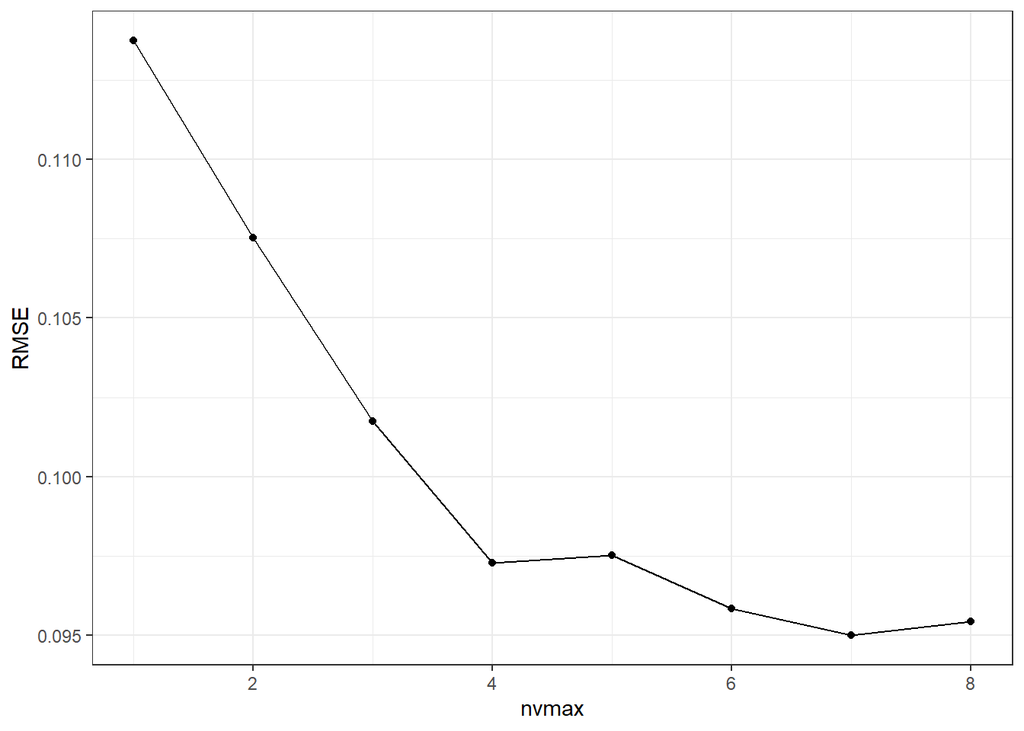

```r
ggplot(fwd_model$results, aes(x=nvmax, y=RMSE)) + geom_point() + geom_line() + theme_bw()
```

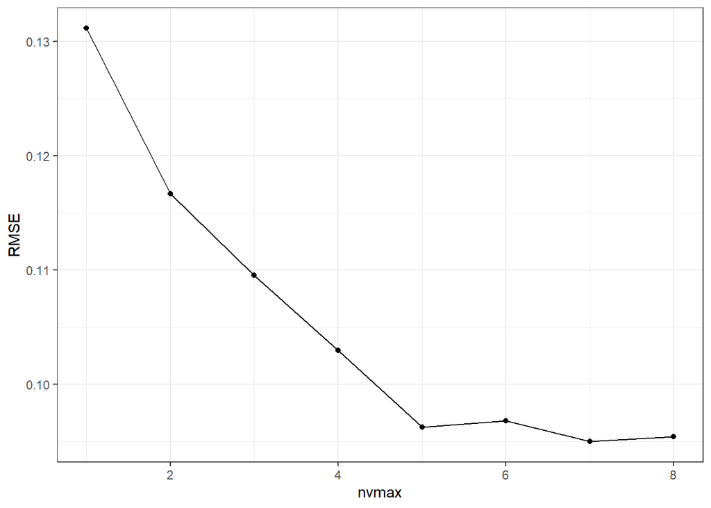

```r
ggplot(bwd_model$results, aes(x=nvmax, y=RMSE)) + geom_point() + geom_line() + theme_bw()
```

forward selection방법과 backward selection방법으로 cross validation 수행했을때 결과 시각화

forward selection과 backward selection의 결과를 봤을때, feature가 5일때와 7일때의 RMSE 값이 0.005도 차이가 나지 않기 때문에, model interpretabliity 측에서 고려할 때 충분히 선택가능하다.

```r
coef5 <- coef(bwd_model$finalModel, 5)
coef5
```

```
##   (Intercept)           MEI        CFC.11        CFC.12           TSI
## -1.323568e+02  6.636007e-02 -5.810908e-03  3.486627e-03  9.688286e-02
##      Aerosols
## -1.665844e+00
```

```r
bwd_coef5 <- coef(reg_bwd, 5)
bwd_coef5
```

```
##   (Intercept)           MEI        CFC.11        CFC.12           TSI
## -1.323568e+02  6.636007e-02 -5.810908e-03  3.486627e-03  9.688286e-02
##      Aerosols
## -1.665844e+00
```

feature 수가 5일때 MEI, CFC.11, CFC.12, TSI, Aerosols 가 포함된다.

### assignment 3-1-5

**Prediction accuracy를 높이기 위해, 기존 8개의 feature들 외에 feature들 사이의 모든 interaction effect, 그리고 CO2, CFC.11, CFC.12의 제곱항들을 모두 추가한 모델을 대상으로 cross validation을 활 용한 stepwise variable selection을 수행해보자.**

**assignment 3-1-5-(a)** **Forward selection과 backward selection의 결과를 비교해보자.**

### 추가된 feature로 linear regression model 생성

```r
model12 <- lm(Temp~(.)^2 + I(CO2^2) + I(CFC.11^2) + I(CFC.12^2), data = climate_train)
summary(model12)
```

```
##
## Call:
## lm(formula = Temp ~ (.)^2 + I(CO2^2) + I(CFC.11^2) + I(CFC.12^2),
##     data = climate_train)
##
## Residuals:
##       Min        1Q    Median        3Q       Max
## -0.208424 -0.046709 -0.005395  0.043205  0.268027
##
## Coefficients:
##                   Estimate Std. Error t value Pr(>|t|)
## (Intercept)     -3.083e+04  1.366e+04  -2.258  0.02501 *
## MEI             -5.712e+01  3.659e+01  -1.561  0.11999
## CO2             -7.231e+00  1.063e+01  -0.680  0.49705
## CH4             -3.547e-01  2.435e+00  -0.146  0.88432
## N2O              1.124e+02  5.089e+01   2.209  0.02830 *
## CFC.11           1.467e+01  9.286e+00   1.580  0.11559
## CFC.12          -1.156e+01  6.231e+00  -1.856  0.06490 .
## TSI              2.335e+01  1.012e+01   2.307  0.02203 *
## Aerosols        -1.100e+03  1.313e+03  -0.837  0.40341
## I(CO2^2)        -2.698e-03  1.231e-03  -2.193  0.02945 *
## I(CFC.11^2)      2.794e-04  7.891e-04   0.354  0.72363
## I(CFC.12^2)      8.651e-05  2.581e-04   0.335  0.73782
## MEI:CO2         -5.474e-04  2.921e-03  -0.187  0.85152
## MEI:CH4          6.775e-04  6.427e-04   1.054  0.29305
## MEI:N2O         -1.785e-02  1.969e-02  -0.906  0.36578
## MEI:CFC.11      -4.699e-04  3.639e-03  -0.129  0.89740
## MEI:CFC.12       1.257e-03  2.218e-03   0.567  0.57139
## MEI:TSI          4.483e-02  2.867e-02   1.564  0.11937
## MEI:Aerosols    -1.811e-01  7.354e-01  -0.246  0.80573
## CO2:CH4          1.945e-04  2.955e-04   0.658  0.51124
## CO2:N2O          1.522e-02  6.082e-03   2.503  0.01309 *
## CO2:CFC.11       9.133e-04  1.041e-03   0.877  0.38149
## CO2:CFC.12      -5.405e-04  6.583e-04  -0.821  0.41254
## CO2:TSI          3.028e-03  8.221e-03   0.368  0.71299
## CO2:Aerosols     1.054e-01  1.980e-01   0.532  0.59501
## CH4:N2O         -8.355e-04  1.109e-03  -0.753  0.45201
## CH4:CFC.11      -6.585e-05  2.201e-04  -0.299  0.76507
## CH4:CFC.12       4.869e-05  1.376e-04   0.354  0.72383
## CH4:TSI          3.933e-04  1.862e-03   0.211  0.83289
## CH4:Aerosols    -2.987e-02  2.888e-02  -1.034  0.30234
## N2O:CFC.11       5.769e-03  3.459e-03   1.668  0.09688 .
## N2O:CFC.12      -2.573e-03  2.242e-03  -1.148  0.25233
## N2O:TSI         -8.537e-02  3.745e-02  -2.280  0.02364 *
## N2O:Aerosols     1.037e+00  6.808e-01   1.524  0.12913
## CFC.11:CFC.12   -4.640e-04  8.636e-04  -0.537  0.59161
## CFC.11:TSI      -1.216e-02  6.903e-03  -1.761  0.07972 .
## CFC.11:Aerosols  6.751e-01  2.296e-01   2.940  0.00365 **
## CFC.12:TSI       9.159e-03  4.725e-03   1.939  0.05391 .
## CFC.12:Aerosols -4.245e-01  1.208e-01  -3.515  0.00054 ***
## TSI:Aerosols     6.024e-01  9.209e-01   0.654  0.51369
## ---
## Signif. codes:  0 '***' 0.001 '**' 0.01 '*' 0.05 '.' 0.1 ' ' 1
##
## Residual standard error: 0.0823 on 208 degrees of freedom
## Multiple R-squared:  0.812,  Adjusted R-squared:  0.7768
## F-statistic: 23.04 on 39 and 208 DF,  p-value: < 2.2e-16
```

### forward selection과 backward selection 결과 비교

**forward selection 실행**

```r
plus_fwd <- regsubsets(Temp~(.)^2 + I(CO2^2) + I(CFC.11^2) + I(CFC.12^2), data = climate_train, nvmax = 39, method ="forward")
plus_fwd_summary <- summary(plus_fwd)
```

```r
max(plus_fwd_summary$adjr2)
```

```
## [1] 0.7806748
```

가장 큰 R2 : 0.7806748

```r
which.max(plus_fwd_summary$adjr2)
```

```
## [1] 25
```

가장 큰 R2을 가질때 feuature 수 : 25

```r
coef_plus_fwd <- coef(plus_fwd, 25)
coef_plus_fwd
```

```
##     (Intercept)             MEI             CO2             N2O          CFC.11
##   -6.766743e+03   -5.037030e+01   -1.375080e+01    3.634369e+01   -3.267599e-01
##             TSI        Aerosols        I(CO2^2)     I(CFC.11^2)     I(CFC.12^2)
##    5.319450e+00   -1.029619e+03   -1.426421e-03   -6.668690e-04   -1.878482e-04
##         MEI:CO2      MEI:CFC.11      MEI:CFC.12         MEI:TSI         CO2:N2O
##    2.727496e-04    3.709700e-03   -6.534111e-04    3.638504e-02    5.229694e-03
##      CO2:CFC.12         CO2:TSI    CO2:Aerosols    CH4:Aerosols      N2O:CFC.11
##    1.421416e-04    9.577741e-03    7.553857e-02   -3.508192e-02    1.285682e-03
##         N2O:TSI    N2O:Aerosols   CFC.11:CFC.12 CFC.11:Aerosols CFC.12:Aerosols
##   -2.821013e-02    6.214198e-01    5.336130e-04    6.236973e-01   -3.910163e-01
##    TSI:Aerosols
##    6.575292e-01
```

feature 수 25 일때 feature들의 계수값

**backward selection 실행**

```r
plus_bwd <- regsubsets(Temp~(.)^2 + I(CO2^2) + I(CFC.11^2) + I(CFC.12^2), data = climate_train, nvmax = 39, method ="backward")
plus_bwd_summary <- summary(plus_bwd)
```

```r
max(plus_bwd_summary$adjr2)
```

```
## [1] 0.7872462
```

가장 큰 R2 : 0.7872462

```r
which.max(plus_bwd_summary$adjr2)
```

```
## [1] 24
```

가장 큰 R2 가질때 feature 수 : 24

```r
coef_plus_bwd <- coef(plus_bwd, 24)
coef_plus_bwd
```

```
##     (Intercept)             MEI             CO2             N2O          CFC.11
##   -2.586632e+04   -6.539512e+01   -2.061252e+00    8.796417e+01    1.230112e+01
##          CFC.12             TSI        I(CO2^2)         MEI:CH4         MEI:N2O
##   -9.737977e+00    1.960734e+01   -3.055789e-03    6.212768e-04   -1.618590e-02
##      MEI:CFC.12         MEI:TSI         CO2:CH4         CO2:N2O         CH4:N2O
##    9.885319e-04    5.044578e-02    2.571290e-04    1.226756e-02   -5.138066e-04
##         CH4:TSI      N2O:CFC.11      N2O:CFC.12         N2O:TSI    N2O:Aerosols
##    4.904520e-05    5.365412e-03   -2.246625e-03   -6.715198e-02    5.298036e-02
##   CFC.11:CFC.12      CFC.11:TSI CFC.11:Aerosols      CFC.12:TSI CFC.12:Aerosols
##   -1.556669e-04   -1.017632e-02    5.874349e-01    7.671716e-03   -3.506853e-01
```

feature 수 24 일때 feature들의 계수값

**assignment 3-1-5-(b)** **Cross validated RMSE가 가장 낮은 best 모델을 결정하자. 어떠한 변수들이 best 모델에 포함되는가?**

```r
library(caret)

set.seed(123)
model_plus_fwd <- train(Temp~(.)^2 + I(CO2^2) + I(CFC.11^2) + I(CFC.12^2), data = climate_train, method = "leapForward", tuneGrid = data.frame(nvmax = 1:39), trControl = trainControl(method="repeatedcv", number =10, repeats = 5))
model_plus_fwd$results
```

```
##    nvmax       RMSE  Rsquared        MAE     RMSESD RsquaredSD      MAESD
## 1      1 0.11391373 0.5888669 0.09043463 0.01600177 0.07980508 0.01301038
## 2      2 0.10733591 0.6332972 0.08575455 0.01619163 0.08744112 0.01318739
## 3      3 0.10048120 0.6841432 0.08116742 0.01562110 0.08452138 0.01225178
## 4      4 0.09686374 0.7050144 0.07725763 0.01655670 0.08951617 0.01363687
## 5      5 0.09563200 0.7133450 0.07600874 0.01588841 0.08617834 0.01319991
## 6      6 0.09381167 0.7228060 0.07430330 0.01604656 0.08953791 0.01339221
## 7      7 0.09355592 0.7233079 0.07385039 0.01584932 0.08563927 0.01280388
## 8      8 0.09117440 0.7371131 0.07165862 0.01568047 0.08040349 0.01279443
## 9      9 0.09004229 0.7437623 0.07075010 0.01465854 0.07211912 0.01152871
## 10    10 0.08713873 0.7600961 0.06795932 0.01467178 0.07091351 0.01145426
## 11    11 0.08547277 0.7681935 0.06618972 0.01434574 0.07005334 0.01129805
## 12    12 0.08473653 0.7718965 0.06571977 0.01415784 0.06872197 0.01136403
## 13    13 0.08461979 0.7722347 0.06554069 0.01427539 0.06888038 0.01137821
## 14    14 0.08449326 0.7728593 0.06548888 0.01429020 0.06924112 0.01167024
```

[output cut: 25 more lines]

10-fold CV 5번 실행한 forward selection

```r
set.seed(123)
model_plus_bwd <- train(Temp~(.)^2 + I(CO2^2) + I(CFC.11^2) + I(CFC.12^2), data = climate_train, method = "leapBackward", tuneGrid = data.frame(nvmax = 1:39), trControl = trainControl(method="repeatedcv", number =10, repeats = 5))
model_plus_bwd$results
```

```
##    nvmax       RMSE  Rsquared        MAE     RMSESD RsquaredSD      MAESD
## 1      1 0.13125765 0.4458752 0.10343957 0.01613691 0.09999349 0.01375298
## 2      2 0.11860230 0.5532065 0.09350733 0.01611472 0.08424145 0.01354410
## 3      3 0.11129866 0.6071414 0.08860355 0.01631278 0.09150610 0.01453876
## 4      4 0.10392228 0.6618165 0.08360050 0.01529589 0.08495502 0.01290235
## 5      5 0.09313941 0.7245887 0.07344564 0.01612055 0.08537789 0.01257689
## 6      6 0.09190459 0.7335184 0.07233312 0.01631547 0.08205752 0.01254871
## 7      7 0.09038030 0.7389921 0.07130304 0.01588934 0.08271383 0.01229751
## 8      8 0.08943588 0.7438747 0.07010238 0.01589705 0.08339877 0.01290467
## 9      9 0.08887996 0.7470338 0.06919790 0.01599303 0.08302473 0.01271495
## 10    10 0.08918956 0.7462854 0.06938910 0.01583203 0.08207158 0.01267331
## 11    11 0.08845124 0.7499327 0.06878662 0.01593956 0.08277472 0.01280449
## 12    12 0.08887502 0.7482570 0.06942817 0.01552393 0.08002016 0.01228217
## 13    13 0.08617303 0.7641596 0.06770762 0.01449683 0.07278084 0.01106441
## 14    14 0.08617302 0.7649722 0.06747029 0.01409316 0.07107004 0.01112226
```

[output cut: 25 more lines]

10-fold CV 5번 실행한 backward selection

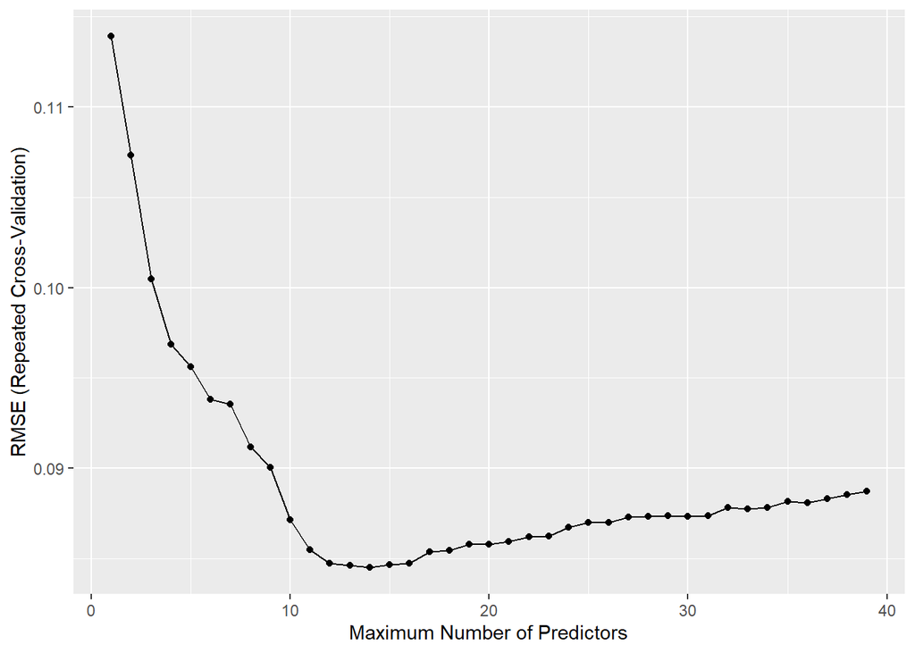

```r
ggplot(model_plus_fwd)
```

forward selection 시각화

```r
min(model_plus_fwd$results$RMSE)
```

```
## [1] 0.08449326
```

```r
which.min(model_plus_fwd$results$RMSE)
```

```
## [1] 14
```

forward selection 결과

feature 수 : 14

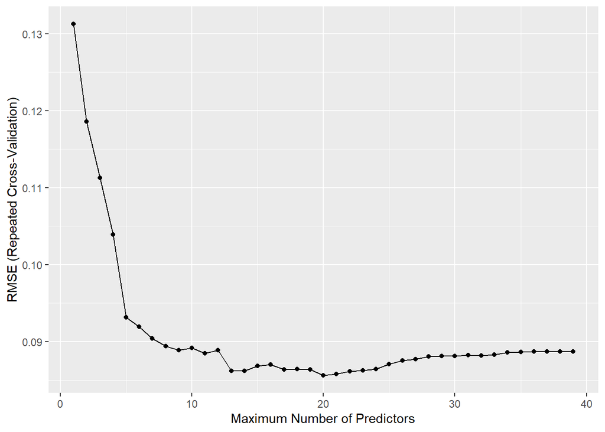

```r
ggplot(model_plus_bwd)
```

backward selectino 시각화

```r
min(model_plus_bwd$results$RMSE)
```

```
## [1] 0.08559444
```

```r
which.min(model_plus_bwd$results$RMSE)
```

```
## [1] 20
```

backward selection 결과

feature 수 : 20

```r
model_plus_bwd$results$RMSE[14]
```

```
## [1] 0.08617302
```

큰 차이가 나지 않기 때문에 forward와 backward를 함께 고려하여 feature = 14 일때 best model로 선정

```r
coef_plus_fwd_cv <- coef(model_plus_bwd$finalModel, 14)
coef_plus_fwd_cv
```

```
##     (Intercept)             CO2             N2O             TSI        I(CO2^2)
##   -4.070834e+03   -1.852026e+00    1.196277e+01    3.690021e+00   -2.254530e-03
##      MEI:CFC.12         CO2:N2O      N2O:CFC.11      N2O:CFC.12         N2O:TSI
##    1.259701e-04    1.119133e-02    5.385128e-03   -2.603666e-03   -1.176168e-02
##   CFC.11:CFC.12      CFC.11:TSI CFC.11:Aerosols      CFC.12:TSI CFC.12:Aerosols
##   -1.111504e-04   -1.193099e-03    6.251181e-01    6.155771e-04   -3.372329e-01
```

```r
coef_plus_bwd_cv <- coef(model_plus_bwd$finalModel, 14)
coef_plus_bwd_cv
```

```
##     (Intercept)             CO2             N2O             TSI        I(CO2^2)
##   -4.070834e+03   -1.852026e+00    1.196277e+01    3.690021e+00   -2.254530e-03
##      MEI:CFC.12         CO2:N2O      N2O:CFC.11      N2O:CFC.12         N2O:TSI
##    1.259701e-04    1.119133e-02    5.385128e-03   -2.603666e-03   -1.176168e-02
##   CFC.11:CFC.12      CFC.11:TSI CFC.11:Aerosols      CFC.12:TSI CFC.12:Aerosols
##   -1.111504e-04   -1.193099e-03    6.251181e-01    6.155771e-04   -3.372329e-01
```

각 경우 포함되는 feature들의 종류 및 계수

### assignment 3-1-6

**2, 3, 4, 5번에서 수립된 4개의 모델에 대해서 test set (2004년 이후 데이터)에 대한 prediction accuracy (RMSE) 를 비교해 보자. 예상한 대로 결과가 나오는가? 그렇지 않다면 그 원인은 무엇일지 분 석해보자**

```r
cv_model_2 <- train(Temp~., data = climate_test, method = "lm", trControl = trainControl(method = "repeatedcv", number = 10, repeats = 10))
cv_model_3 <- train(Temp~MEI+TSI+Aerosols+N2O, data = climate_test, method = "lm", trControl = trainControl(method = "repeatedcv", number = 10, repeats = 10))
cv_model_4 <- train(Temp~MEI + CFC.11 + CFC.12 + TSI + Aerosols, data = climate_test, method = "lm", trControl = trainControl(method = "repeatedcv", number = 10, repeats = 10))
cv_model_5 <- train(Temp~CO2 + N2O + TSI + I(CO2^2) + MEI:CFC.12 + CO2:N2O + N2O:CFC.11 + N2O:CFC.12 + N2O:TSI + CFC.11:CFC.12 + CFC.11:TSI + CFC.11:Aerosols + CFC.12:TSI + CFC.12:Aerosols, data = climate_test, method = "lm", trControl = trainControl(method = "repeatedcv", number = 10, repeats = 10))
```

```r
summary(resamples(list(model_2 = cv_model_2,model_3 = cv_model_3, model_4 = cv_model_4, model_5 = cv_model_5 )))
```

```
##
## Call:
## summary.resamples(object = resamples(list(model_2 = cv_model_2, model_3
##  = cv_model_3, model_4 = cv_model_4, model_5 = cv_model_5)))
##
## Models: model_2, model_3, model_4, model_5
## Number of resamples: 100
##
## MAE
##               Min.    1st Qu.     Median       Mean    3rd Qu.      Max. NA's
## model_2 0.01664781 0.04238701 0.05447303 0.05652464 0.06792338 0.1045237    0
## model_3 0.01280644 0.03763273 0.05063008 0.05333605 0.06519082 0.1187694    0
## model_4 0.02258075 0.04228944 0.05034310 0.05594831 0.06614670 0.1175144    0
## model_5 0.02288439 0.04286184 0.05164891 0.05544977 0.06526059 0.1070478    0
##
## RMSE
##               Min.    1st Qu.     Median       Mean    3rd Qu.      Max. NA's
## model_2 0.01715840 0.05329792 0.06468104 0.07064780 0.08290051 0.1402939    0
## model_3 0.01419321 0.04965285 0.06392913 0.06748051 0.07976399 0.1434094    0
## model_4 0.02761921 0.05220070 0.06292441 0.07002854 0.07927270 0.1487520    0
## model_5 0.02825432 0.05035209 0.05945978 0.06641235 0.07384311 0.1267008    0
##
## Rsquared
##                 Min.   1st Qu.    Median      Mean   3rd Qu.      Max. NA's
## model_2 0.0005104914 0.2537552 0.5278913 0.4808484 0.7064472 0.9616078    0
## model_3 0.0005150422 0.3553422 0.5507231 0.5305327 0.7471417 0.9669576    0
## model_4 0.0060415155 0.3291496 0.5909918 0.5373823 0.7431085 0.9907456    0
## model_5 0.0039197168 0.3981253 0.6155371 0.5686133 0.7735063 0.9842686    0
```

### assignment 2

***Regression on simulated Data**

**(i) rnorm() 함수를 활용해서 표준정규분포로부터 길이가 100인 feature vector 를 생성하고, 평균이 0, 표준편차가 3인 정규분포로부터 길이가 100인 오차 vector 을 생성한다. (ii) 길이가 100인 target vector 를 다음 식을 사용하여 생성한다.**

**assignment 2-1**

**x, x2, x3, …x10 의 10개 변수를 feature로, 를 target으로 설정하자. 이때 feature 변수들과 target 변수 사이의 상관관계를 시각화해보자.**

```r
set.seed(321)
x <- rnorm(100)
e <- rnorm(100, 0, 3)
x2 <- x^2
x3 <- x^3
x4 <- x^4
x5 <- x^5
x6 <- x^6
x7 <- x^7
x8 <- x^8
x9 <- x^9
x10 <- x^10
y <- 1+ 2*x + 3*x2 + 4*x3 + e
```

feature 변수 10개와 target 변수 1개 설정

```r
model_xy <- data.frame(x=x, x2=x2, x3=x3, x4=x4, x5=x5, x6=x6, x7=x7, x8=x8, x9=x9, x10=x10, y=y)
str(model_xy)
```

```
## 'data.frame':    100 obs. of  11 variables:
##  $ x  : num  1.705 -0.712 -0.278 -0.12 -0.124 ...
##  $ x2 : num  2.9067 0.507 0.0773 0.0143 0.0154 ...
##  $ x3 : num  4.95563 -0.361 -0.02148 -0.00171 -0.0019 ...
##  $ x4 : num  8.448876 0.257048 0.005972 0.000205 0.000236 ...
##  $ x5 : num  1.44e+01 -1.83e-01 -1.66e-03 -2.45e-05 -2.93e-05 ...
##  $ x6 : num  2.46e+01 1.30e-01 4.61e-04 2.93e-06 3.63e-06 ...
##  $ x7 : num  4.19e+01 -9.28e-02 -1.28e-04 -3.51e-07 -4.50e-07 ...
##  $ x8 : num  7.14e+01 6.61e-02 3.57e-05 4.20e-08 5.58e-08 ...
##  $ x9 : num  1.22e+02 -4.70e-02 -9.91e-06 -5.03e-09 -6.91e-09 ...
##  $ x10: num  2.07e+02 3.35e-02 2.76e-06 6.01e-10 8.57e-10 ...
##  $ y  : num  29.04 -3.1 3.99 3.25 -2.73 ...
```

feature 변수 10개와 target 변수 1개를 포함한 dataframe 생성

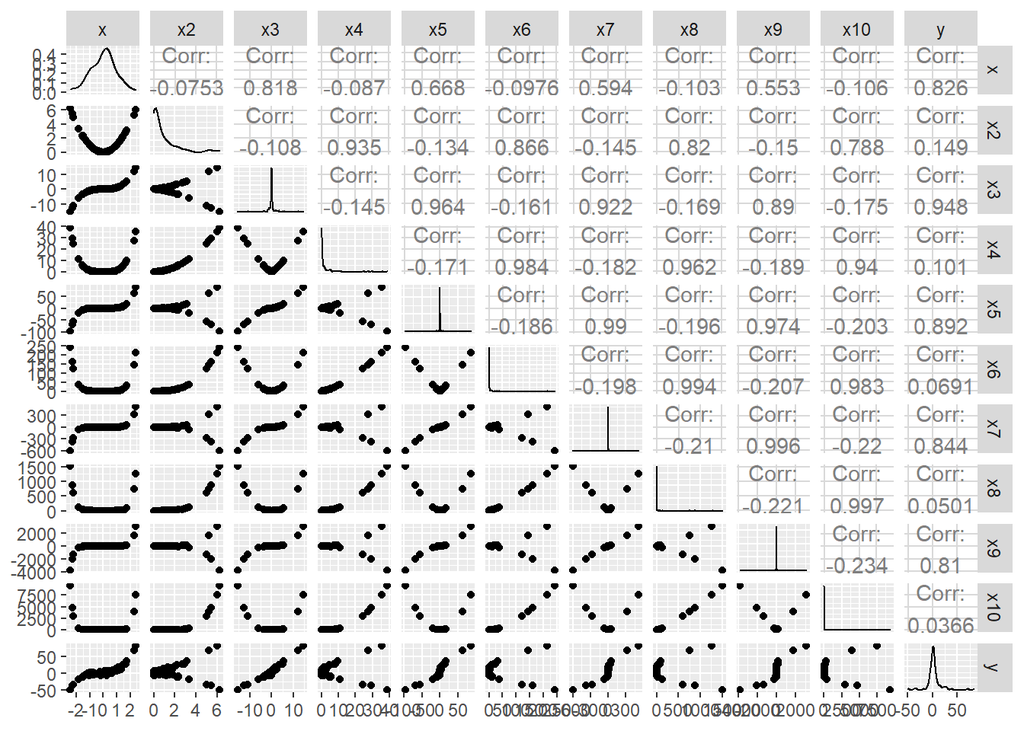

```r
library(GGally)
vis <- ggpairs(model_xy)
vis
```

ggpairs 함수를 통해 상관관계 시각화

target 변수 y와 feature 변수 x, x3, x5, x7, x9가높은 상관관계를 갖고 있음을 알 수 있다.

**assignment 2-2**

```r
re_model <- lm(y~., data = model_xy)
summary(re_model)
```

```
##
## Call:
## lm(formula = y ~ ., data = model_xy)
##
## Residuals:
##     Min      1Q  Median      3Q     Max
## -8.5149 -1.3527 -0.0133  1.7705  6.1180
##
## Coefficients:
##             Estimate Std. Error t value Pr(>|t|)
## (Intercept)  0.98241    0.55073   1.784   0.0779 .
## x            3.63840    1.59271   2.284   0.0247 *
## x2           2.18886    3.45904   0.633   0.5285
## x3           1.72562    3.48033   0.496   0.6212
## x4           2.27129    5.00393   0.454   0.6510
## x5           1.10922    2.23877   0.495   0.6215
## x6          -1.55667    2.56118  -0.608   0.5449
## x7          -0.21778    0.52753  -0.413   0.6807
## x8           0.36174    0.51939   0.696   0.4879
## x9           0.01501    0.04109   0.365   0.7158
## x10         -0.02690    0.03606  -0.746   0.4576
## ---
## Signif. codes:  0 '***' 0.001 '**' 0.01 '*' 0.05 '.' 0.1 ' ' 1
##
## Residual standard error: 2.845 on 89 degrees of freedom
## Multiple R-squared:  0.9696, Adjusted R-squared:  0.9662
## F-statistic: 284.1 on 10 and 89 DF,  p-value: < 2.2e-16
```

모든 feature 변수를 포함하는 회귀분석식 실행

feature 변수 x가 그나마 유의한 변수이다.

B1:2 B2:3 B3:4

estimate B1:3.63849 B2:2.18886 B3:1.72562

증가하는 방향이나 관계가 크게 비슷하지 않다는 것을 알 수 있다.

**assignment 2-3**

```r
re_model2 <- lm(y~x+x2+x3, data=model_xy)
summary(re_model2)
```

```
##
## Call:
## lm(formula = y ~ x + x2 + x3, data = model_xy)
##
## Residuals:
##     Min      1Q  Median      3Q     Max
## -8.3198 -1.6165  0.0293  1.7825  6.2534
##
## Coefficients:
##             Estimate Std. Error t value Pr(>|t|)
## (Intercept)   1.0559     0.3361   3.142  0.00224 **
## x             2.2998     0.5076   4.531 1.69e-05 ***
## x2            2.9288     0.2103  13.929  < 2e-16 ***
## x3            3.9866     0.1460  27.313  < 2e-16 ***
## ---
## Signif. codes:  0 '***' 0.001 '**' 0.01 '*' 0.05 '.' 0.1 ' ' 1
##
## Residual standard error: 2.774 on 96 degrees of freedom
## Multiple R-squared:  0.9688, Adjusted R-squared:  0.9679
## F-statistic: 994.9 on 3 and 96 DF,  p-value: < 2.2e-16
```

feature 변수 x, x2, x3를 포함하는 회귀분석식 실행

모든 feature 변수들이 통계적으로 유의하다는 것을 알 수 있다.

B1:2 B2:3 B3:4

estimate B1:2.2998 B2:2.9288 B3:3.9866

실제 B와 estimate B값이 거의 비슷하다는 것을 알 수 있다.

**assignmet 2-4**

### 데이터 전처리

```r
library(rsample)
split <- initial_split(model_xy, prop = 0.7, strata = "y")
model_train <- training(split)
model_test <- testing(split)
```

training set과 test set으로 분리

```r
library(glmnet)
```

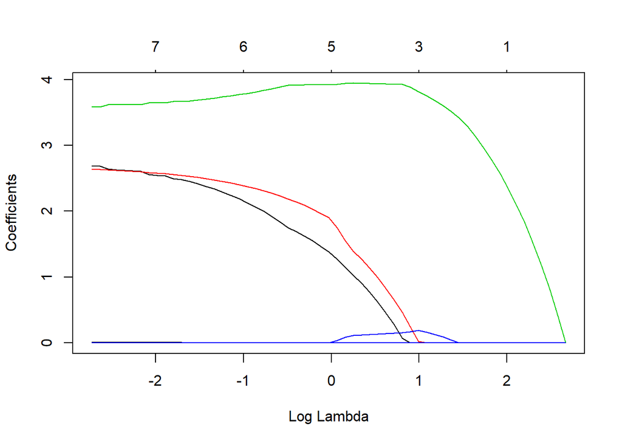

```r
a <- model.matrix(y~.,model_train)[,-1]
b <- model_train$y

lasso_model <- glmnet(x = a, y = b, alpha = 1)
plot(lasso_model, xvar = "lambda")
```

glmnet 함수를 이용해 lasso regression 실행

**cross validation**

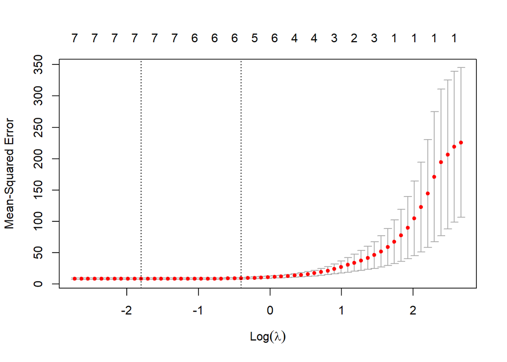

```r
set.seed(123)
cv_lasso <- cv.glmnet(x = a, y = b, alpha = 1, nfolds = 10)
plot(cv_lasso)
```

10-cv 실행

```r
best_lasso <- cv_lasso$lambda.min
best_lasso
```

```
## [1] 0.1657651
```

```r
library(caret)
testX <- model.matrix(y~., model_test)[,-1]
lasso_pred <- predict(lasso_model, s = best_lasso, newx = testX)
RMSE(lasso_pred, model_test$y )
```

```
## [1] 2.777908
```

최적의 람다값과 그 값을 가지는 model의 RMSE값

```r
predict(lasso_model, s=best_lasso, type = "coefficients")[1:10,]
```

```
##  (Intercept)            x           x2           x3           x4           x5
## 1.3544141635 2.4919147530 2.5541633395 3.6665839564 0.0000000000 0.0001869148
##           x6           x7           x8           x9
## 0.0000000000 0.0050228496 0.0000000000 0.0006316046
```